# Analiza zbioru danych graczy NBA

Author

Kosharnyi Bohdan

# Wstęp

Otrzymaliśmy taki zbiór danych:

| Pos | Age | G | GS | MP | FG | FGA | FG. | X3P | X3PA | X3P. | X2P | X2PA | X2P. | eFG. | FT | FTA | FT. | ORB | DRB | TRB | AST | STL | BLK | TOV | PF | PTS | ID |
| --- | --- | --- | --- | --- | --- | --- | --- | --- | --- | --- | --- | --- | --- | --- | --- | --- | --- | --- | --- | --- | --- | --- | --- | --- | --- | --- | --- |
| C | 26.88 | 38.00 | 13.00 | 13.94 | 2.01 | 4.15 | 0.48 | 0.00 | 0.00 | 0.00 | 2.01 | 4.15 | 0.48 | 0.48 | 0.64 | 1.18 | 0.52 | 1.29 | 2.01 | 3.33 | 0.66 | 0.31 | 0.56 | 1.04 | 2.27 | 4.66 | 1 |
| PF | 23.00 | 38.00 | 0.80 | 9.60 | 1.70 | 3.64 | 0.47 | 0.18 | 0.58 | 0.23 | 1.50 | 3.06 | 0.49 | 0.49 | 0.94 | 1.22 | 0.80 | 0.72 | 1.30 | 2.02 | 0.48 | 0.20 | 0.12 | 0.66 | 1.20 | 4.52 | 2 |
| C | 31.00 | 34.14 | 3.43 | 14.49 | 2.26 | 4.39 | 0.51 | 0.00 | 0.00 | 0.00 | 2.26 | 4.39 | 0.51 | 0.51 | 1.11 | 1.46 | 0.75 | 0.91 | 1.96 | 2.87 | 0.39 | 0.20 | 0.66 | 0.90 | 2.29 | 5.60 | 3 |
| PF | 32.15 | 73.38 | 46.46 | 28.14 | 3.22 | 6.65 | 0.48 | 0.09 | 0.42 | 0.15 | 3.12 | 6.24 | 0.49 | 0.48 | 2.05 | 2.92 | 0.70 | 2.49 | 4.68 | 7.17 | 1.05 | 0.77 | 0.28 | 0.96 | 1.65 | 8.57 | 4 |
| C | 23.00 | 8.00 | 0.00 | 7.60 | 0.50 | 2.60 | 0.19 | 0.00 | 0.00 | 0.00 | 0.50 | 2.60 | 0.19 | 0.19 | 0.00 | 0.00 | 0.00 | 1.50 | 1.30 | 2.80 | 0.00 | 0.10 | 0.00 | 0.40 | 1.60 | 1.00 | 5 |
| SG | 23.50 | 75.50 | 9.00 | 20.60 | 4.05 | 9.30 | 0.44 | 0.05 | 0.40 | 0.14 | 3.95 | 8.85 | 0.45 | 0.44 | 1.70 | 2.20 | 0.77 | 0.90 | 1.20 | 2.10 | 2.15 | 0.40 | 0.15 | 1.35 | 1.90 | 9.85 | 6 |

# Budowanie Modelu liniowego

Najpierw zbudujemy macierz korelacji, żeby nie wprowadzić skorelowane między sobą zmienne do modelu.

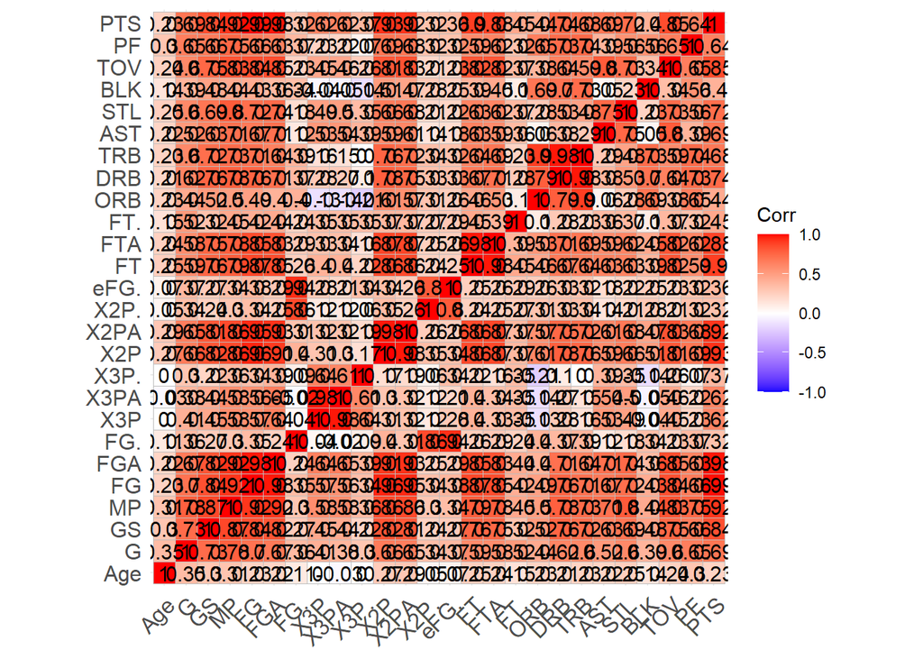

Age, G, X3P, X2P, eFG., DRB, STL - zmienne, które będą wchodzić do modelu pełnego.

A teraz za pomocą funkcji *step* znajdziemy najlepszy model według kryteria AIC.

Dopasowany model ma postać:
$$MP \sim \displaystyle\beta_0 + \beta_1 \cdot X2P + \beta_2 \cdot X3P + \beta_3 \cdot STL +\beta_4 \cdot G + \beta_5 \cdot DRB + \beta_6 \cdot Age + \beta_6 \cdot eFG. + \varepsilon$$
Współczynnik determinacji $R^2$ wynosi $0.927$ i wpływ wszystkich zmiennych, oprócz współczynnika wolnego, jest istotny.

Zbudujemy wykresy diagnostyczne modelu.

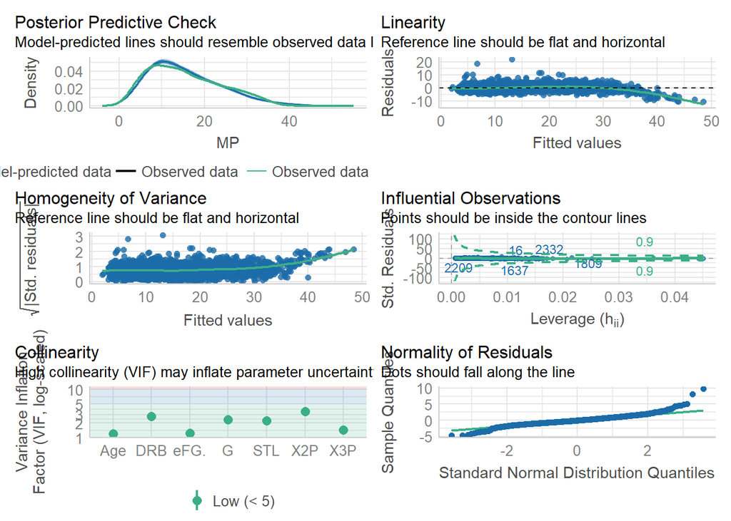

Z powyższych wykresów widzimy, że nie występuje nadmiarowość zmiennych modelu, charakter zależność pomiędzy predyktorami a *MP* jest nieliniowy oraz reszty modelu nie są normalne. A zatem spróbujmy transformować zmienne modelu.

## Transformacja zmiennych

Narysujemy wykresy zależności pomiędzy predyktorami modelu oraz zmienną objaśnianą.

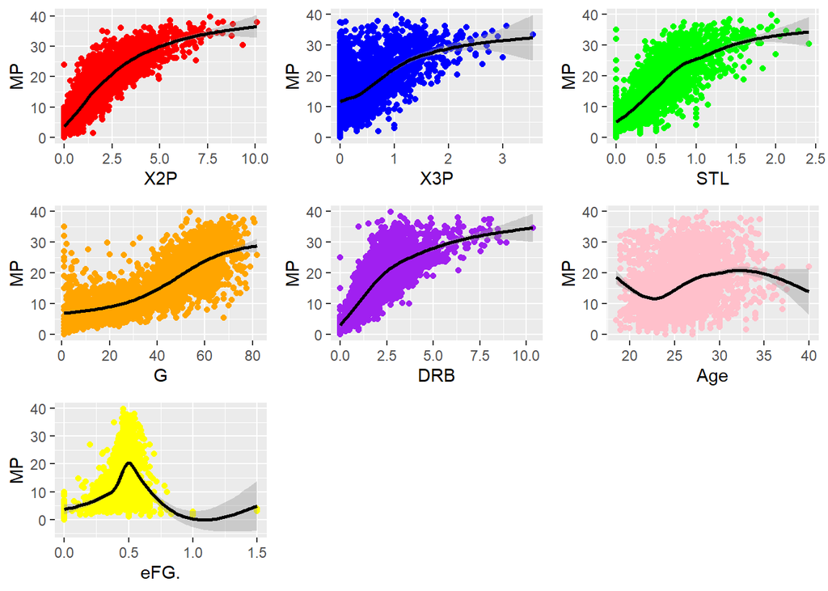

Najpierw spróbujemy zlogarytmować wszystkie zmienne modelu.

Wykresy diagnostyczne dla modelu po zlogarytmowaniu wszystkich zmiennych będą miały następującą postać:

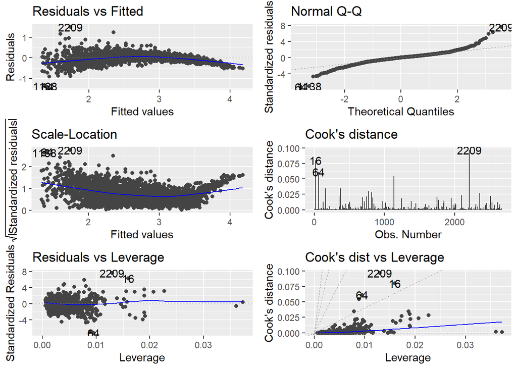

Takie transformacji nie polepszyli modelu, a zatem zastosujmy transformacje *Yeo-Johnsona* do naszych zmiennych objaśniających.

Wykresy diagnostyczne modelu po transformacji zmiennych objaśniających.

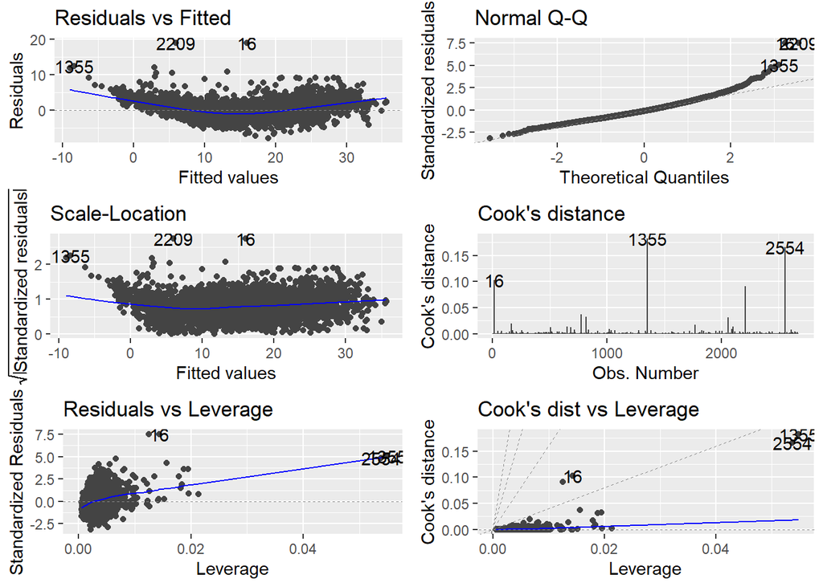

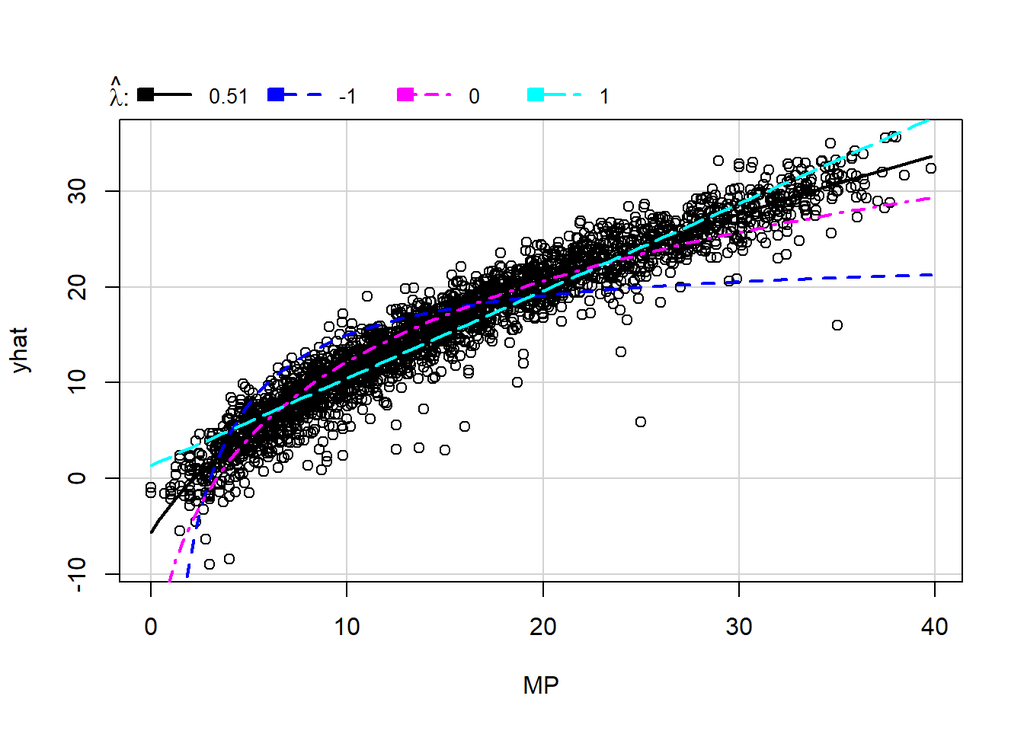

```
      lambda      RSS
1  0.5111491 12174.67
2 -1.0000000 69218.44
3  0.0000000 17457.60
4  1.0000000 15657.24
```

Z powyższego wykresu widzimy, że współ czynnik transformacji $\lambda =0.5111491$, co w “przybliżeniu” uznamy za $\frac{1}{2}$.

Sprawdzimy, jak po transformacji zmiennej *MP* wyglądają wykresy diagnostyczne modelu.

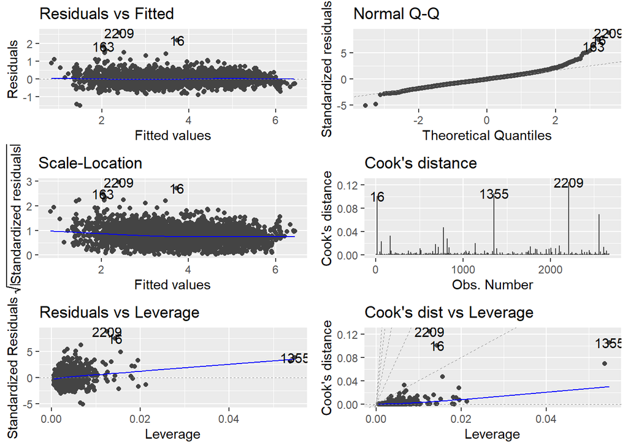

Nadal widzimy, że rozkład reszt może być istotnie różny od normalnego.

## Odporne Estematory White’a

Zastosujmy do modelu z transformowanymi zmiennymi odporne estymatory White’a.

```
t test of coefficients:

               Estimate  Std. Error t value  Pr(>|t|)
(Intercept) -1.3367e+01  1.3537e+00 -9.8743 < 2.2e-16 ***
Age          1.5401e+01  1.4098e+00 10.9242 < 2.2e-16 ***
X3P          1.7274e+00  5.2311e-02 33.0223 < 2.2e-16 ***
X2P          1.4992e+00  6.6254e-02 22.6286 < 2.2e-16 ***
eFG.        -8.0798e-01  9.8927e-02 -8.1674 4.808e-16 ***
DRB          8.8392e-01  3.6664e-02 24.1090 < 2.2e-16 ***
STL          1.2305e+00  7.8946e-02 15.5862 < 2.2e-16 ***
G            5.1851e-03  5.7221e-04  9.0615 < 2.2e-16 ***
---
Signif. codes:  0 '***' 0.001 '**' 0.01 '*' 0.05 '.' 0.1 ' ' 1
```

Wszystkie zmienne z nowymi, bardziej efektywnymi estymatorami, są istotne.

## Wartości odstające

Obserwacji mające duży wpływ na współczynniki modelu:

| Numer obserwacji | β0 | β1 | β2 | β3 | β4 | β5 | β6 | β7 |
| --- | --- | --- | --- | --- | --- | --- | --- | --- |
| 16 | -0.395 | 0.398 | 0.592 | 0.572 | -0.253 | -0.063 | -0.5804863 | -0.4483266 |
| 817 | -0.075 | 0.075 | 0.264 | 0.283 | -0.095 | 0.110 | -0.3089501 | -0.2745736 |
| 2209 | 0.097 | -0.091 | 0.116 | 0.904 | -0.295 | -0.657 | -0.4285698 | -0.1986654 |

Obserwacji o dużej dźwigni i resztach standaryzowanych:

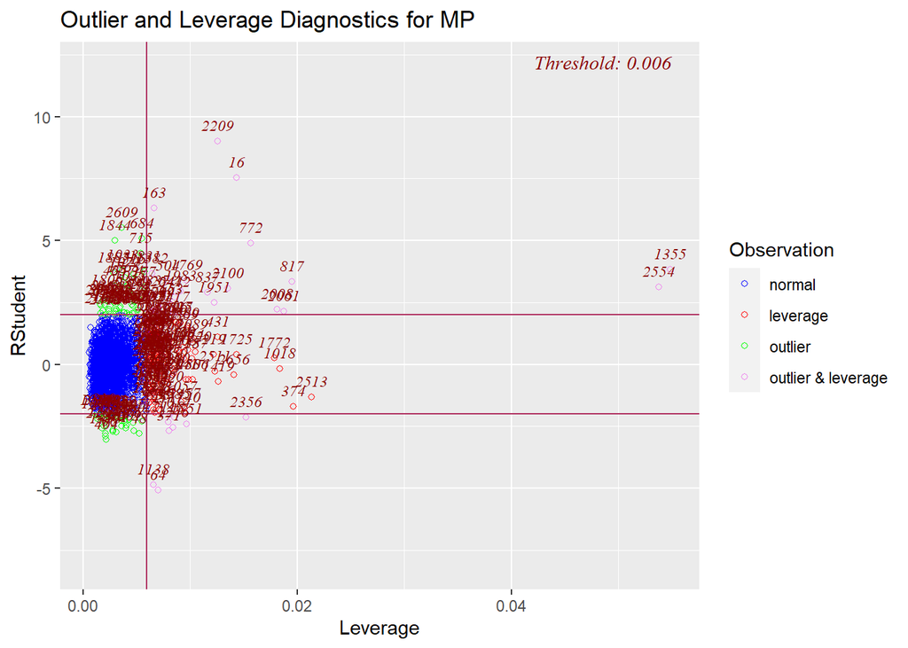

Obserwacji o dużej odległości Cooka:

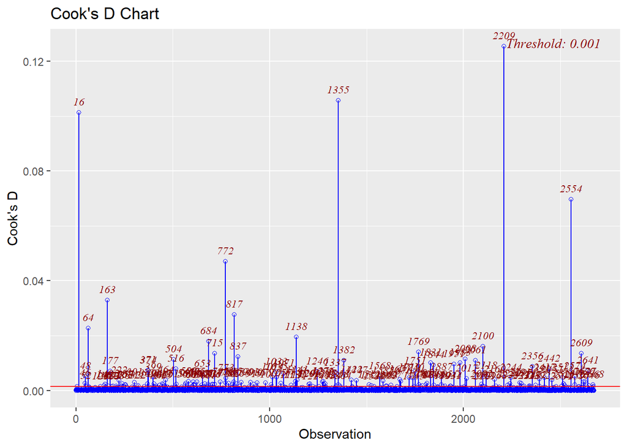

Rozpatrywany zbiór raczej nie ma obserwacji odstających, bo mimo tego, że istnieją obserwacji o dużej dźwigni i dużym wpływie ma współczynniki modelu, nie są one błędem wprowadzania danych, po prostu model jest zły, w sensie opisu tego zjawiska.

## Testy diagnostyczne

Mimo tego, że na wykresach diagnostycznych możemy odczytać nie spełnienie niektórych założeń, sprawdzimy to testami. Model liniowy ma spełniać następujące założenia:

1. Charakter zależności musi być liniowy.
2. $E(\varepsilon|X_i)\neq 0$.
3. $Var(\varepsilon|X_i)\neq \sigma^2$.
4. $Cov(\varepsilon_i,\varepsilon_j)\neq 0$.
5. Predyktory wykazują nadmiarowość (redundancja, współliniowość).
6. Próba na podstawie, której estymujemy model nie jest reprezentatywna. 6.Rozkład błędów dopasowania nie jest normalny.
7. Model zawiera jedną lub więcej obserwacji odstających.
8. Liczba predyktorów przekracza liczbę obserwacji.

### Normalonść rozkładu reszt

| Test | p-value |
| --- | --- |
| Lilliefors | 0 |
| Anderson-Darling | 0 |

Test Lillieforsa i test Andersona-Darlinga odrzucają hipotezę o normalności reszt. Ale zbiór, na którym był zbudowany model, zawiera $2674$ obserwacji, co oznacza, że nawet przy użyciu testów zakładających normalność rozkładu, mając tak dużą liczebność próby możemy odpuszczić tą założenie ze względu na to, że dla testów zbiór będzie się zachowywał asymptotycznie normalnie.

### Jednorodność wariancji

| Test | p-value |
| --- | --- |
| Breusch-Pagan | 0 |
| White | 0 |
| Goldfeld-Quandt | 1 |
| Harrison-McCabe | 1 |

Test Breuscha-Pagana, test Whitea odrzucają hipotezę o jednorodności wariancji, ale korzystając z odpornych estymatorów White’a możemy załatwić ten problem.

### Seryjna korelacja reszt

| Test | p-value |
| --- | --- |
| Durbin-Watson | 0.2544 |
| Breusch-Godfrey rzędu 2 | 0.0058 |
| Breusch-Godfrey rzędu 3 | 0.0106 |
| Breusch-Godfrey rzędu 4 | 0.0107 |

### Liniowy ksztalt zależności

| Test | p-value |
| --- | --- |
| RESET | 0.0000 |
| Rainbow | 0.0797 |
| Harvey-Collier | 0.3103 |

Test RESET Ramseya odrzucaja hipotezę o liniowej postaci zależności pomiędzy zmienną *MP* a predyktorami, ale jest to spowodowane szybką rosnącą mocą testu, czyli trzeba było by sprawdzić, czy zmienią się wyniki testu dla $200$ obserwacji wylosowanych z całej próby.

| Test | p-value |
| --- | --- |
| RESET | 0.033 |

Podsumowując wyniki testów i wykresów diagnostycznych widzimy, że zbudowany model nie spełnia wszystkich założeń modelu liniowego, ale to najlepszy model z przestrzeni modeli liniowych, opisujący tą zależność.

# Predykcja modelu

Zobaczymy jak dobrą predykcje możemy zrobić na podstawie zbudowanego modelu. Badamy to na innym zbiorze, który zawiera w sobie statystyki ukraińskich koszykarze.

| Season | Player | GP | MIN | FGM | FGA | X3PM | X3PA | FTM | FTA | TOV | PF | ORB | DRB | REB | AST | STL | BLK | PTS | birth_year | height_cm | weight_kg |
| --- | --- | --- | --- | --- | --- | --- | --- | --- | --- | --- | --- | --- | --- | --- | --- | --- | --- | --- | --- | --- | --- |
| 2011 | Randy Culpepper | 51 | 1,687.8 | 372 | 838 | 116 | 336 | 283 | 360 | 136 | 127 | 33 | 95 | 128 | 189 | 84 | 14 | 1,143 | 1,989 | 183 | 74 |
| 2011 | R.T. Guinn | 52 | 1,446.0 | 299 | 625 | 115 | 272 | 174 | 208 | 71 | 135 | 77 | 247 | 324 | 81 | 43 | 30 | 887 | 1,981 | 208 | 111 |
| 2011 | Jeremy Chappell | 52 | 1,702.7 | 290 | 607 | 66 | 201 | 124 | 160 | 91 | 136 | 104 | 244 | 348 | 188 | 96 | 10 | 770 | 1,987 | 191 | 83 |
| 2011 | Shawn King | 44 | 1,352.8 | 293 | 489 | 1 | 2 | 172 | 250 | 114 | 124 | 186 | 264 | 450 | 112 | 44 | 104 | 759 | 1,984 | 208 | 100 |
| 2011 | Steve Burtt | 40 | 1,296.6 | 259 | 540 | 71 | 195 | 165 | 205 | 133 | 100 | 12 | 113 | 125 | 200 | 57 | 5 | 754 | 1,984 | 185 | 84 |
| 2011 | Ramel Curry | 48 | 1,308.5 | 256 | 551 | 86 | 193 | 88 | 106 | 114 | 91 | 46 | 163 | 209 | 134 | 66 | 11 | 686 | 1,980 | 191 | 86 |

Żeby sprawdzić jak dobrą predykcje ma nasz model, zbudujmy tabele, zawierającą wartość dopasowaną z modelu oraz wartość prawdziwą ze zbioru.

| Obserwacja | Wartość dopasowana z modelu | Lewy koniec | Prawy koniec | Wartość ze zbioru |
| --- | --- | --- | --- | --- |
| 1 | 24.338 | 18.955 | 30.392 | 26.868 |
| 2 | 19.239 | 14.486 | 24.665 | 21.381 |
| 3 | 19.102 | 14.366 | 24.512 | 19.6 |
| 4 | 14.497 | 10.419 | 19.248 | 18.793 |
| 5 | 22.071 | 16.953 | 27.864 | 26.306 |
| 6 | 19.179 | 14.436 | 24.593 | 20.096 |
| 7 | 15.011 | 10.859 | 19.834 | 18.238 |
| 8 | 14.736 | 10.623 | 19.521 | 18.159 |
| 9 | 22.186 | 17.063 | 27.981 | 20.893 |
| 10 | 22.669 | 17.488 | 28.521 | 20.064 |

Z powyższej tabeli widzimy, że predykcja modelu liniowego jest dość dobra. Ten fakt zwizualizujemy.

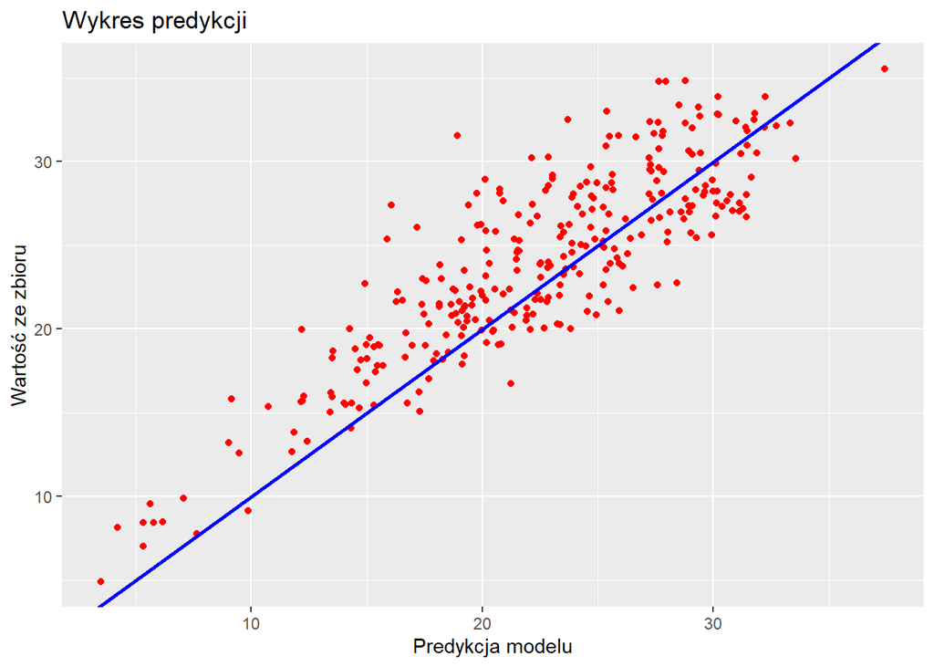

Możemy zauważyć, że na dole model niedoszacowuje wartości, a na górze przeszacowuje, ale to tylko model liniowy, więc można było spodziewać się tego.

# Interpretacja

Wzrost zmiennej $\left(1-(Age+1)^{-1}\right)^{2}$ na 1 powoduje wzrost *MP* na $15.4^{2} = 237.16$.

Wzrost zmiennej $\left(\frac{(1-(X3P+1)^{-2})}{2}\right)^{2}$ na 1 powoduje wzrost *MP* na $1.727^{2} = 2.982529$.

Wzrost zmiennej $\left(2(1-(1-X2P)^{-\frac{1}{2}})\right)^{2}$ na 1 powoduje wzrost *MP* na $1.499^{2} = 2.247001$.

Wzrost zmiennej $eFG.^{2}$ na 1 powoduje spadek *MP* na $0.808^{2} = 0.652864$.

Wzrost zmiennej $\left(5(1-(1-DRB)^{-\frac{1}{5}})\right)^{2}$ na 1 powoduje wzrost *MP* na $0.8839^{2} = 0.7812792$.

Wzrost zmiennej $\left(\frac{5(1-(STL-1)^{-\frac{4}{5}})}{4}\right)^{2}$ na 1 powoduje wzrost *MP* na $1.23^{2} = 1.5129$.

# Inne modeli

## Regresja MARS

Multivariate Adaptive Regression Splines (MARS) jest procedurą nieparametryczną, nie wymagającą założeń na temat funkcyjnej zależności między zmiennymi zależnymi, a niezależnymi. MARS modeluje tę zależność za pomocą zbioru współczynników i funkcji bazowych, “wyprowadzanych” wyłącznie z danych. Otóż, przestrzeń wejściowa dzielona jest na obszary, w których określane są osobne funkcje regresyjne lub klasyfikacyjne. Takie podejście czyni MARS szczególnie użytecznym przy większej liczbie wymiarów na wejściu (więcej niż dwie zmienne), kiedy, w przypadku innych technik zagrażać zaczyna problem wymiarowości. Dopasujmy regresje MARS do zbioru bez transformacji.

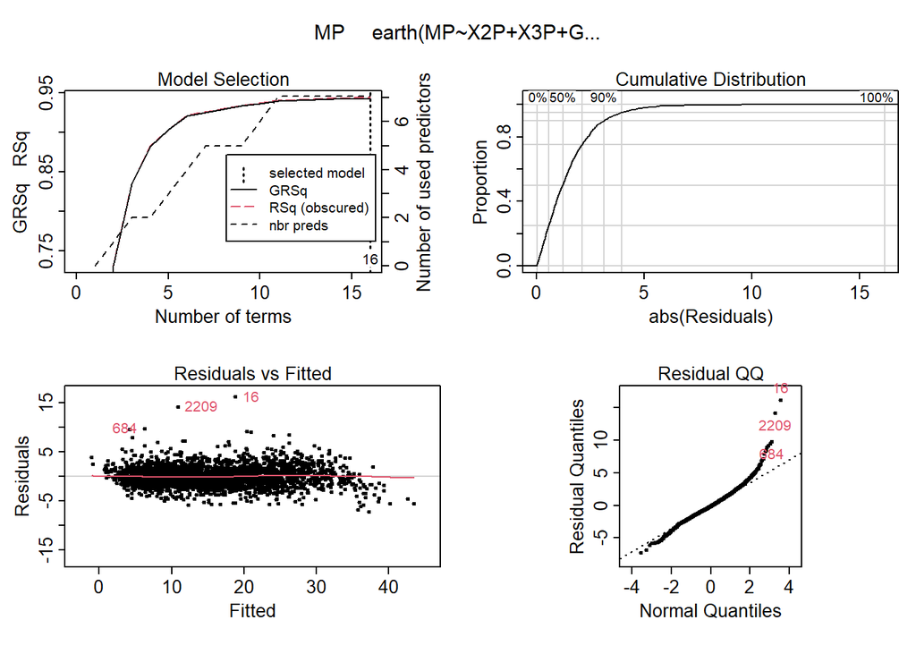

Sprawdźmy predykcje otrzymanego modelu.

| Obserwacja | Wartość dopasowana z modelu | Wartość ze zbioru |
| --- | --- | --- |
| 1 | 24.568 | 26.868 |
| 2 | 19.645 | 21.381 |
| 3 | 18.639 | 19.600 |
| 4 | 16.413 | 18.793 |
| 5 | 22.086 | 26.306 |
| 6 | 19.057 | 20.096 |
| 7 | 13.777 | 18.238 |
| 8 | 16.278 | 18.159 |
| 9 | 22.322 | 20.893 |
| 10 | 21.185 | 20.064 |

Predykcja tego modelu nie jest lepsza od modelu z transformowanymi zmiennymi, ale interpretacja jest bardzo łatwiejsza.

### Interpretacja

```
Call: earth(formula=MP~X2P+X3P+G+STL+DRB+Age+eFG., data=df)

                coefficients
(Intercept)       -60.522023
h(2.68889-X2P)     -2.979341
h(X2P-2.68889)      1.649034
h(1.212-X3P)       -4.836944
h(X3P-1.212)        1.643505
h(G-1.75)           3.649853
h(25.5-G)           3.660178
h(G-25.5)          -3.587503
h(0.733333-STL)    -5.331621
h(STL-0.733333)     3.121643
h(2.25-DRB)        -2.164973
h(DRB-2.25)         0.849165
h(31-Age)          -0.167919
h(Age-31)          -0.133237
h(0.298-eFG.)      -4.621199
h(eFG.-0.298)      -6.873230

Selected 16 of 16 terms, and 7 of 7 predictors
Termination condition: RSq changed by less than 0.001 at 16 terms
Importance: X2P, X3P, DRB, STL, G, eFG., Age
Number of terms at each degree of interaction: 1 15 (additive model)
GCV 4.113749    RSS 10746.59    GRSq 0.9424746    RSq 0.9437587
```

Podsumowanie tego modelu interpretujemy w następujący sposób:

Jeżeli gracz rzuca więcej niż $2.689$ skutecznych 2-punktowych rzutów za mecz, to wzrost zmiennej *X2P* na $1$ powoduje wzrost *MP* (minut na boisku) na $1.65$.

Jeżeli gracz rzuca więcej niż $1.212$ skutecznych 3-punktowych rzutów za mecz, to wzrost zmiennej *X3P* na $1$ powoduje wzrost *MP* (minut na boisku) na $1.64$.

Jeżeli gracz gra więcej niż $1.75$ mecze za sezon, to wzrost zmiennej *G* na $1$ powoduje wzrost *MP* na $3.65$.

Jeżeli gracz robi więcej niż $0.73$ przechwyty za mecz, to wzrost zmiennej *STL* na 1 powoduje wzrost *MP* na $3.12$.

Jeżeli gracz ma więcej niż $31$ lat, to wzrost zmiennej *Age* na 1 powoduje spadek *MP* na $0.133$.

Jeżeli gracz ma większą niż $0.298$ efektywność rzutów, to wzrost zmiennej *eFG.* na 1 powoduje spadek *MP* na $6.87$.

## Regresja kwantylowa

Regresja kwantylowa modeluje relację między zbiorem predyktorów (zmiennych niezależnych) i konkretnych centyli (lub kwantyli) zmiennej przewidywanej (zależnej), najczęściej medianę. Ma dwie główne przewagi nad zwykłą regresją metodą najmniejszych kwadratów:

-W regresji kwantylowej nie przyjmuje się żadnych założeń dotyczących rozkładu zmiennej przewidywanej.

-Regresja kwantylowa jest odporna na wpływy obserwacji odstających.

Spróbujmy dopasować regresje kwantylową i sprawdzić ją predykcje.

| Obserwacja | Kwantyl 10% | Kwantyl 20% | Kwantyl 30% | Kwantyl 40% | Kwantyl 50% | Kwantyl 60% | Kwantyl 70% | Kwantyl 80% | Kwantyl 90% | Wartość ze zbioru |
| --- | --- | --- | --- | --- | --- | --- | --- | --- | --- | --- |
| 1 | 21.095 | 22.387 | 23.655 | 24.436 | 25.353 | 26.098 | 26.923 | 27.713 | 29.518 | 26.868 |
| 2 | 18.087 | 18.852 | 19.628 | 20.338 | 20.781 | 21.359 | 22.164 | 22.788 | 23.478 | 21.381 |
| 3 | 16.374 | 17.52 | 18.525 | 19.207 | 20.007 | 20.681 | 21.404 | 22.031 | 23.801 | 19.6 |
| 4 | 14.526 | 15.496 | 16.293 | 17.025 | 17.444 | 17.889 | 18.774 | 19.612 | 20.889 | 18.793 |
| 5 | 20.865 | 21.79 | 22.782 | 23.617 | 24.081 | 24.685 | 25.616 | 26.134 | 27.246 | 26.306 |
| 6 | 16.216 | 17.023 | 17.862 | 18.56 | 19.025 | 19.597 | 20.394 | 20.967 | 21.953 | 20.096 |
| 7 | 10.345 | 11.224 | 11.874 | 12.404 | 12.872 | 13.39 | 13.893 | 14.594 | 15.74 | 18.238 |
| 8 | 13.367 | 14.164 | 14.889 | 15.516 | 15.891 | 16.363 | 17.075 | 17.749 | 18.71 | 18.159 |
| 9 | 16.642 | 17.746 | 18.74 | 19.449 | 20.119 | 20.644 | 21.51 | 22.426 | 23.933 | 20.893 |
| 10 | 16.97 | 18.019 | 19.005 | 19.75 | 20.364 | 21.051 | 21.786 | 22.6 | 23.824 | 20.064 |

Narysujmy wykres predykcji regresji kwantylowej.

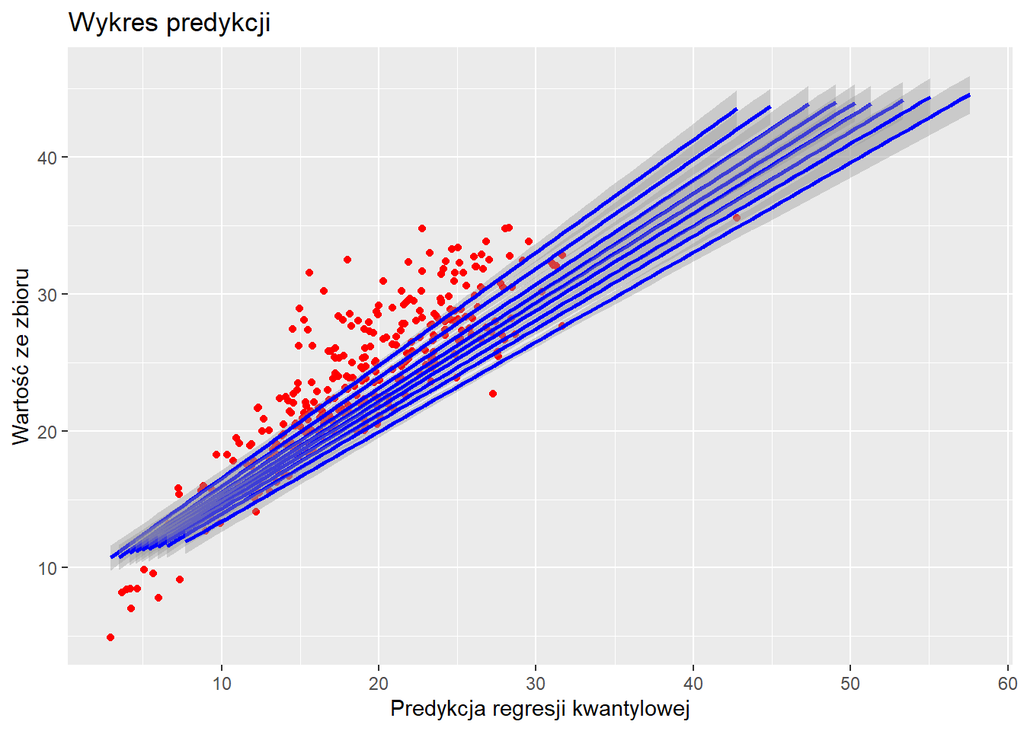

### Interpretacja

```
Call: rq(formula = model, tau = seq(0.1, 0.9, by = 0.1), data = df)

tau: [1] 0.1

Coefficients:
            Value    Std. Error t value  Pr(>|t|)
(Intercept) -2.07092  0.56838   -3.64356  0.00027
X2P          1.74822  0.12304   14.20897  0.00000
X3P          3.66610  0.16729   21.91488  0.00000
STL          5.27208  0.32498   16.22263  0.00000
G            0.08103  0.00543   14.93329  0.00000
DRB          1.14036  0.12089    9.43276  0.00000
Age          0.12377  0.02243    5.51894  0.00000
eFG.        -1.47537  0.52173   -2.82787  0.00472

Call: rq(formula = model, tau = seq(0.1, 0.9, by = 0.1), data = df)

tau: [1] 0.2

Coefficients:
            Value    Std. Error t value  Pr(>|t|)
(Intercept) -1.55549  0.36924   -4.21268  0.00003
X2P          1.87315  0.08596   21.79133  0.00000
X3P          3.83726  0.16510   23.24137  0.00000
STL          5.20919  0.24921   20.90249  0.00000
G            0.07716  0.00434   17.78808  0.00000
DRB          1.21374  0.08801   13.79092  0.00000
Age          0.12589  0.01381    9.11719  0.00000
eFG.        -1.52596  0.40927   -3.72849  0.00020

Call: rq(formula = model, tau = seq(0.1, 0.9, by = 0.1), data = df)

tau: [1] 0.3

Coefficients:
            Value    Std. Error t value  Pr(>|t|)
(Intercept) -1.21251  0.50124   -2.41901  0.01563
X2P          1.97972  0.09865   20.06720  0.00000
X3P          4.04564  0.19573   20.66924  0.00000
STL          5.29070  0.26105   20.26734  0.00000
```

[output cut: 79 more lines]

```

Call: rq(formula = model, tau = seq(0.1, 0.9, by = 0.1), data = df)

tau: [1] 0.9

Coefficients:
            Value    Std. Error t value  Pr(>|t|)
(Intercept)  1.80535  0.58149    3.10469  0.00192
X2P          2.57265  0.10540   24.40825  0.00000
X3P          4.81412  0.18842   25.54994  0.00000
STL          5.36312  0.32256   16.62650  0.00000
G            0.04010  0.00657    6.10367  0.00000
DRB          1.61636  0.09583   16.86783  0.00000
Age          0.17066  0.02113    8.07501  0.00000
eFG.        -4.37471  0.66214   -6.60696  0.00000
```

Zinterpretujemy wyniki otrzymane dla $\tau = 0.3$.

# Podsumowanie

Zbudowaliśmy 3 modeli opisujące badany związek. Reasumując otrzymane wyniki możemy zrobić wniosek, że mimo tego że predykcja modeli nie bardzo się różni, ale interpretacja modelu z transformowanymi zmiennymi jest tak trudna, że jest on najmniej możliwy do stosowania, w przypadku regresji kwantylowej jest nieco lepiej, ale najbardziej sensowną interpretacje otrzymujemy przy stosowaniu MARS.

Do czego moglibyśmy zastosować taki model? Np., młody koszykarz mógłby, korzystając z tego modelu, wybierać jaki ze swoich umiejętności mu trzeba polepszyć, żeby otrzymywać więcej czasu na boisku za mecz.